# LOTKA-VOLTERRA

## ¿Que es el modelo Lotka-Volterra?

Modelo que representa un modelo escalatorio que se relaciona con la presentacion Presa-Depredador

Este código simula cómo interactúan dos especies a lo largo del tiempo en un modelo de tipo depredador-presa, generando un gráfico que muestra la evolución de ambas poblaciones en función del tiempo. Los parámetros a, b, c, y e determinan las tasas de crecimiento, mortalidad, y las interacciones entre las especies.

```python
%matplotlib inline
import matplotlib.pyplot as plt
from random import *
from numpy import *
import sys
```

```python
# model parameters
a = 0.7; b = 0.5; c = 0.3;  e = 0.2
dt = 0.001; max_time = 100
```

```python
# initial time and populations
t = 0; x = 1.0; y = 0.5
```

```python
# empty lists in which to store time and populations
t_list = []; x_list = []; y_list = []
```

```python
# initialize lists
t_list.append(t); x_list.append(x); y_list.append(y)
```

```python
while t < max_time:
    # calc new values for t, x, y
    t = t + dt
    x = x + (a*x - b*x*y)*dt
    y = y + (-c*y + e*x*y)*dt

 # store new values in lists
    t_list.append(t)
    x_list.append(x)
    y_list.append(y)
```

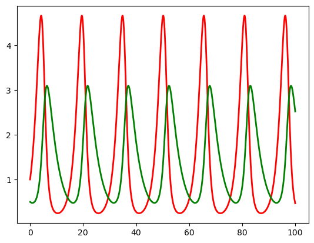

```python
# Plot the results
p = plt.plot(t_list, x_list, 'r', t_list, y_list, 'g', linewidth = 2)
```

## Cambio 1:

```python
%matplotlib inline
import matplotlib.pyplot as plt
from random import *
from numpy import *
import sys
```

```python
# model parameters
a = 0.7; b = 0.5; c = 0.5;  e = 0.2
dt = 0.001; max_time = 100
```

```python
# initial time and populations
t = 0; x = 1.0; y = 0.5
```

```python
# empty lists in which to store time and populations
t_list = []; x_list = []; y_list = []
```

```python
# initialize lists
t_list.append(t); x_list.append(x); y_list.append(y)
```

```python
while t < max_time:
    # calc new values for t, x, y
    t = t + dt
    x = x + (a*x - b*x*y)*dt
    y = y + (-c*y + e*x*y)*dt

    # store new values in lists
    t_list.append(t)
    x_list.append(x)
    y_list.append(y)
```

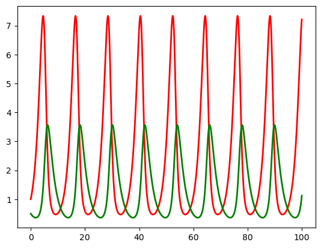

```python
# Plot the results
p = plt.plot(t_list, x_list, 'r', t_list, y_list, 'g', linewidth = 2)
```

## Cambio 2:

Disminuir la tasa de encuentro entre depredadores y presas (parámetro b) Parámetros Originales: b = 0.5 Nuevo Valor: b = 0.3 Disminuir b significa que la tasa de encuentro y, por lo tanto, la depredación de y sobre x se reduce. Esto debería permitir que la población de presas x crezca más, mientras que la población de depredadores y podría tener más dificultades para encontrar comida. Efecto en el Gráfico: La población de presas x debería crecer más rápidamente, mientras que la población de depredadores y podría decrecer debido a la falta de alimento.

```python
%matplotlib inline
import matplotlib.pyplot as plt
from random import *
from numpy import *
import sys
```

```python
# model parameters
a = 0.7; b = 0.3; c = 0.3;  e = 0.2
dt = 0.001; max_time = 100
```

```python
# initial time and populations
t = 0; x = 1.0; y = 0.5
```

```python
# empty lists in which to store time and populations
t_list = []; x_list = []; y_list = []
```

```python
# initialize lists
t_list.append(t); x_list.append(x); y_list.append(y)
```

```python
while t < max_time:
    # calc new values for t, x, y
    t = t + dt
    x = x + (a*x - b*x*y)*dt
    y = y + (-c*y + e*x*y)*dt

    # store new values in lists
    t_list.append(t)
    x_list.append(x)
    y_list.append(y)
```

```python
# Plot the results
p = plt.plot(t_list, x_list, 'r', t_list, y_list, 'g', linewidth = 2)
```

[output not shown]

## Cambio 3:

Aumentar la tasa de interacción favorable entre las presas y los depredadores (parámetro e) Parámetros Originales: e = 0.2 Nuevo Valor: e = 0.4 Aumentar e significa que la tasa a la que la población de depredadores y se beneficia d la presencia de la población de presas x es mayor. Esto podría hacer que la población de depredadores crezca más rápidamente cuando hay suficientes presas disponibles. Efecto en el Gráfico: Podríamos observar un incremento en la población de depredadores y debido a la mayor eficiencia en la captura de presas, lo que también podría estabilizar la población de presas x a un nivel más bajo.

```python
%matplotlib inline
import matplotlib.pyplot as plt
from random import *
from numpy import *
import sys
```

```python
# model parameters
a = 0.7; b = 0.5; c = 0.3;  e = 0.4
dt = 0.001; max_time = 100
```

```python
# initial time and populations
t = 0; x = 1.0; y = 0.5
```

```python
# empty lists in which to store time and populations
t_list = []; x_list = []; y_list = []
```

```python
# initialize lists
t_list.append(t); x_list.append(x); y_list.append(y)
```

```python
while t < max_time:
    # calc new values for t, x, y
    t = t + dt
    x = x + (a*x - b*x*y)*dt
    y = y + (-c*y + e*x*y)*dt

    # store new values in lists
    t_list.append(t)
    x_list.append(x)
    y_list.append(y)
```

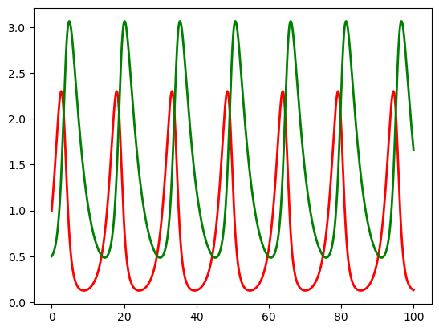

```python
# Plot the results
p = plt.plot(t_list, x_list, 'r', t_list, y_list, 'g', linewidth = 2)
```

## Cambio 4:

Disminuir la tasa de crecimiento de las presas (parámetro a) Parámetros Originales: a = 0.7 Nuevo Valor: a = 0.4 Disminuir a representa una tasa de crecimiento más lenta para la población de presas x. Con una tasa de crecimiento más baja, la población de presas puede crecer más lentamente o incluso disminuir si la depredación es alta. Efecto en el Gráfico: La población de presas x crecerá más lentamente, y podríamos ver una reducción en las oscilaciones generales de la población de depredadores y también debido a la menor disponibilidad de alimento.

```python
%matplotlib inline
import matplotlib.pyplot as plt
from random import *
from numpy import *
import sys
```

```python
# model parameters
a = 0.4; b = 0.5; c = 0.3;  e = 0.2
dt = 0.001; max_time = 100
```

```python
# initial time and populations
t = 0; x = 1.0; y = 0.5
```

```python
# empty lists in which to store time and populations
t_list = []; x_list = []; y_list = []
```

```python
# initialize lists
t_list.append(t); x_list.append(x); y_list.append(y)
```

```python
while t < max_time:
    # calc new values for t, x, y
    t = t + dt
    x = x + (a*x - b*x*y)*dt
    y = y + (-c*y + e*x*y)*dt

    # store new values in lists
    t_list.append(t)
    x_list.append(x)
    y_list.append(y)
```

```python
# Plot the results
p = plt.plot(t_list, x_list, 'r', t_list, y_list, 'g', linewidth = 2)
```

[output not shown]

## Cambio 5:

Aumentar el tiempo máximo de simulación (parámetro max_time) Parámetros Originales: max_time = 100 Nuevo Valor: max_time = 200 Aumentar el tiempo máximo permitirá observar las dinámicas de la población durante un período más largo, lo que podría mostrar patrones más complejos de oscilación entre las poblaciones de presas y depredadores. Efecto en el Gráfico: El gráfico se extenderá en el tiempo, mostrando más ciclos de interacción entre las poblaciones “x” y “y”

```python
%matplotlib inline
import matplotlib.pyplot as plt
from random import *
from numpy import *
import sys
```

```python
# model parameters
a = 0.7; b = 0.5; c = 0.3;  e = 0.2
dt = 0.001; max_time = 200
```

```python
# initial time and populations
t = 0; x = 1.0; y = 0.5
```

```python
# empty lists in which to store time and populations
t_list = []; x_list = []; y_list = []
```

```python
# initialize lists
t_list.append(t); x_list.append(x); y_list.append(y)
```

```python
while t < max_time:
    # calc new values for t, x, y
    t = t + dt
    x = x + (a*x - b*x*y)*dt
    y = y + (-c*y + e*x*y)*dt

    # store new values in lists
    t_list.append(t)
    x_list.append(x)
    y_list.append(y)
```

```python
# Plot the results
p = plt.plot(t_list, x_list, 'r', t_list, y_list, 'g', linewidth = 2)
```

[output not shown]